# R Notebook

ANALYTICS PROJECT

# Principal Components Analysis

```r
View(X2013_2017_Citywide_Math_Results_Gender)
summary(X2013_2017_Citywide_Math_Results_Gender)
```

```
    Grade                Year        Category         Number Tested
 Length:70          Min.   :2013   Length:70          Min.   : 24947
 Class :character   1st Qu.:2014   Class :character   1st Qu.: 33196
 Mode  :character   Median :2015   Mode  :character   Median : 34603
                    Mean   :2015                      Mean   : 57687
                    3rd Qu.:2016                      3rd Qu.: 36258
                    Max.   :2017                      Max.   :216698
 Mean Scale Score    Level1_N        Level1_%        Level2_N
 Min.   :289.0    Min.   : 8245   Min.   :25.30   Min.   : 8146
 1st Qu.:299.0    1st Qu.:10348   1st Qu.:30.75   1st Qu.: 9821
 Median :302.0    Median :11622   Median :33.60   Median :10767
 Mean   :301.1    Mean   :19635   Mean   :34.15   Mean   :18094
 3rd Qu.:304.0    3rd Qu.:13144   3rd Qu.:37.27   3rd Qu.:11732
 Max.   :309.0    Max.   :82906   Max.   :46.00   Max.   :71436
    Level2_%        Level3_N        Level3_%        Level4_N
 Min.   :23.40   Min.   : 4049   Min.   :13.80   Min.   : 1994
 1st Qu.:29.52   1st Qu.: 5794   1st Qu.:17.10   1st Qu.: 4367
 Median :31.30   Median : 7246   Median :19.65   Median : 5658
 Mean   :31.47   Mean   :11218   Mean   :19.35   Mean   : 8740
 3rd Qu.:32.88   3rd Qu.: 7932   3rd Qu.:21.07   3rd Qu.: 7033
 Max.   :38.70   Max.   :41148   Max.   :25.40   Max.   :35584
    Level4_%       Level3+4_N      Level3+4_%
 Min.   : 6.50   Min.   : 6252   Min.   :21.40
 1st Qu.:11.62   1st Qu.:10386   1st Qu.:29.85
 Median :15.60   Median :12518   Median :35.45
 Mean   :15.02   Mean   :19958   Mean   :34.38
 3rd Qu.:18.02   3rd Qu.:14408   3rd Qu.:38.80
 Max.   :23.00   Max.   :74906   Max.   :46.00
```

```r
head(X2013_2017_Citywide_Math_Results_Gender,5)
```

|  | Grade | Year | Category | Number Tested | Mean Scale Score | Level1_N | Level1_% | Level2_N | Level2_% | Level3_N | Level3_% | Level4_N | Level4_% | Level3+4_N | Level3+4_% |
| --- | --- | --- | --- | --- | --- | --- | --- | --- | --- | --- | --- | --- | --- | --- | --- |
| 1 | 3 | 2013 | Female | 35415 | 300 | 11179 | 31.6 | 12601 | 35.6 | 7266 | 20.5 | 4369 | 12.3 | 11635 | 32.9 |
| 2 | 3 | 2014 | Female | 35159 | 302 | 10116 | 28.8 | 11397 | 32.4 | 8524 | 24.2 | 5122 | 14.6 | 13646 | 38.8 |
| 3 | 3 | 2015 | Female | 34986 | 303 | 10288 | 29.4 | 11335 | 32.4 | 7715 | 22.1 | 5648 | 16.1 | 13363 | 38.2 |
| 4 | 3 | 2016 | Female | 35596 | 305 | 9272 | 26.0 | 11681 | 32.8 | 7565 | 21.3 | 7078 | 19.9 | 14643 | 41.1 |
| 5 | 3 | 2017 | Female | 34249 | 307 | 8665 | 25.3 | 9862 | 28.8 | 8028 | 23.4 | 7694 | 22.5 | 15722 | 45.9 |

Removing ‘All Grades’ rows

```r
MathResults=X2013_2017_Citywide_Math_Results_Gender[-c(31:35,66:70),]
MathResults
```

|  | Grade | Year | Category | Number Tested | Mean Scale Score | Level1_N | Level1_% | Level2_N | Level2_% | Level3_N | Level3_% | Level4_N | Level4_% | Level3+4_N | Level3+4_% |
| --- | --- | --- | --- | --- | --- | --- | --- | --- | --- | --- | --- | --- | --- | --- | --- |
| 1 | 3 | 2013 | Female | 35415 | 300 | 11179 | 31.6 | 12601 | 35.6 | 7266 | 20.5 | 4369 | 12.3 | 11635 | 32.9 |
| 2 | 3 | 2014 | Female | 35159 | 302 | 10116 | 28.8 | 11397 | 32.4 | 8524 | 24.2 | 5122 | 14.6 | 13646 | 38.8 |
| 3 | 3 | 2015 | Female | 34986 | 303 | 10288 | 29.4 | 11335 | 32.4 | 7715 | 22.1 | 5648 | 16.1 | 13363 | 38.2 |
| 4 | 3 | 2016 | Female | 35596 | 305 | 9272 | 26.0 | 11681 | 32.8 | 7565 | 21.3 | 7078 | 19.9 | 14643 | 41.1 |
| 5 | 3 | 2017 | Female | 34249 | 307 | 8665 | 25.3 | 9862 | 28.8 | 8028 | 23.4 | 7694 | 22.5 | 15722 | 45.9 |
| 6 | 4 | 2013 | Female | 34614 | 300 | 10257 | 29.6 | 12219 | 35.3 | 7575 | 21.9 | 4563 | 13.2 | 12138 | 35.1 |
| 7 | 4 | 2014 | Female | 34588 | 304 | 9806 | 28.4 | 10828 | 31.3 | 7619 | 22.0 | 6335 | 18.3 | 13954 | 40.3 |
| 8 | 4 | 2015 | Female | 34592 | 302 | 10140 | 29.3 | 10864 | 31.4 | 7437 | 21.5 | 6151 | 17.8 | 13588 | 39.3 |
| 9 | 4 | 2016 | Female | 34631 | 304 | 10326 | 29.8 | 9877 | 28.5 | 7225 | 20.9 | 7203 | 20.8 | 14428 | 41.7 |
| 10 | 4 | 2017 | Female | 35146 | 303 | 10208 | 29.0 | 10996 | 31.3 | 6841 | 19.5 | 7101 | 20.2 | 13942 | 39.7 |

[output cut: 50 more lines]

having only ‘All Grades’ rows

```r
AllGrades=X2013_2017_Citywide_Math_Results_Gender[-c(1:30,36:65),]
AllGrades
```

|  | Grade | Year | Category | Number Tested | Mean Scale Score | Level1_N | Level1_% | Level2_N | Level2_% | Level3_N | Level3_% | Level4_N | Level4_% | Level3+4_N | Level3+4_% |
| --- | --- | --- | --- | --- | --- | --- | --- | --- | --- | --- | --- | --- | --- | --- | --- |
| 31 | All Grades | 2013 | Female | 205112 | 299 | 72091 | 35.1 | 71436 | 34.8 | 38920 | 19.0 | 22665 | 11.1 | 61585 | 30.0 |
| 32 | All Grades | 2014 | Female | 197517 | 303 | 63325 | 32.1 | 64743 | 32.8 | 41148 | 20.8 | 28301 | 14.3 | 69449 | 35.2 |
| 33 | All Grades | 2015 | Female | 193914 | 303 | 61152 | 31.5 | 62697 | 32.3 | 40176 | 20.7 | 29889 | 15.4 | 70065 | 36.1 |
| 34 | All Grades | 2016 | Female | 192900 | 304 | 59150 | 30.7 | 61802 | 32.0 | 38032 | 19.7 | 33916 | 17.6 | 71948 | 37.3 |
| 35 | All Grades | 2017 | Female | 191343 | 304 | 59859 | 31.3 | 57715 | 30.2 | 39202 | 20.5 | 34567 | 18.1 | 73769 | 38.6 |
| 66 | All Grades | 2013 | Male | 216698 | 297 | 82906 | 38.3 | 70367 | 32.5 | 38770 | 17.9 | 24655 | 11.4 | 63425 | 29.3 |
| 67 | All Grades | 2014 | Male | 209858 | 300 | 74846 | 35.7 | 64936 | 30.9 | 40542 | 19.3 | 29534 | 14.1 | 70076 | 33.4 |
| 68 | All Grades | 2015 | Male | 205208 | 300 | 72379 | 35.3 | 62261 | 30.3 | 39150 | 19.1 | 31418 | 15.3 | 70568 | 34.4 |
| 69 | All Grades | 2016 | Male | 204080 | 301 | 70592 | 34.6 | 60739 | 29.8 | 37376 | 18.3 | 35373 | 17.3 | 72749 | 35.6 |
| 70 | All Grades | 2017 | Male | 202401 | 301 | 70918 | 35.0 | 56577 | 28.0 | 39322 | 19.4 | 35584 | 17.6 | 74906 | 37.0 |

```r
allgfemales=AllGrades[-c(6:10),]
allgmales=AllGrades[-c(1:5),]
allgfemales
```

|  | Grade | Year | Category | Number Tested | Mean Scale Score | Level1_N | Level1_% | Level2_N | Level2_% | Level3_N | Level3_% | Level4_N | Level4_% | Level3+4_N | Level3+4_% |
| --- | --- | --- | --- | --- | --- | --- | --- | --- | --- | --- | --- | --- | --- | --- | --- |
| 31 | All Grades | 2013 | Female | 205112 | 299 | 72091 | 35.1 | 71436 | 34.8 | 38920 | 19.0 | 22665 | 11.1 | 61585 | 30.0 |
| 32 | All Grades | 2014 | Female | 197517 | 303 | 63325 | 32.1 | 64743 | 32.8 | 41148 | 20.8 | 28301 | 14.3 | 69449 | 35.2 |
| 33 | All Grades | 2015 | Female | 193914 | 303 | 61152 | 31.5 | 62697 | 32.3 | 40176 | 20.7 | 29889 | 15.4 | 70065 | 36.1 |
| 34 | All Grades | 2016 | Female | 192900 | 304 | 59150 | 30.7 | 61802 | 32.0 | 38032 | 19.7 | 33916 | 17.6 | 71948 | 37.3 |
| 35 | All Grades | 2017 | Female | 191343 | 304 | 59859 | 31.3 | 57715 | 30.2 | 39202 | 20.5 | 34567 | 18.1 | 73769 | 38.6 |

```r
allgmales
```

|  | Grade | Year | Category | Number Tested | Mean Scale Score | Level1_N | Level1_% | Level2_N | Level2_% | Level3_N | Level3_% | Level4_N | Level4_% | Level3+4_N | Level3+4_% |
| --- | --- | --- | --- | --- | --- | --- | --- | --- | --- | --- | --- | --- | --- | --- | --- |
| 66 | All Grades | 2013 | Male | 216698 | 297 | 82906 | 38.3 | 70367 | 32.5 | 38770 | 17.9 | 24655 | 11.4 | 63425 | 29.3 |
| 67 | All Grades | 2014 | Male | 209858 | 300 | 74846 | 35.7 | 64936 | 30.9 | 40542 | 19.3 | 29534 | 14.1 | 70076 | 33.4 |
| 68 | All Grades | 2015 | Male | 205208 | 300 | 72379 | 35.3 | 62261 | 30.3 | 39150 | 19.1 | 31418 | 15.3 | 70568 | 34.4 |
| 69 | All Grades | 2016 | Male | 204080 | 301 | 70592 | 34.6 | 60739 | 29.8 | 37376 | 18.3 | 35373 | 17.3 | 72749 | 35.6 |
| 70 | All Grades | 2017 | Male | 202401 | 301 | 70918 | 35.0 | 56577 | 28.0 | 39322 | 19.4 | 35584 | 17.6 | 74906 | 37.0 |

all grade N

```r
lvlfgrade=allgfemales[,c(6,8,10,12,14)]
lvlmgrade=allgmales[,c(6,8,10,12,14)]
lvlfgrade
```

|  | Level1_N | Level2_N | Level3_N | Level4_N | Level3+4_N |
| --- | --- | --- | --- | --- | --- |
| 31 | 72091 | 71436 | 38920 | 22665 | 61585 |
| 32 | 63325 | 64743 | 41148 | 28301 | 69449 |
| 33 | 61152 | 62697 | 40176 | 29889 | 70065 |
| 34 | 59150 | 61802 | 38032 | 33916 | 71948 |
| 35 | 59859 | 57715 | 39202 | 34567 | 73769 |

```r
lvlmgrade
```

|  | Level1_N | Level2_N | Level3_N | Level4_N | Level3+4_N |
| --- | --- | --- | --- | --- | --- |
| 66 | 82906 | 70367 | 38770 | 24655 | 63425 |
| 67 | 74846 | 64936 | 40542 | 29534 | 70076 |
| 68 | 72379 | 62261 | 39150 | 31418 | 70568 |
| 69 | 70592 | 60739 | 37376 | 35373 | 72749 |
| 70 | 70918 | 56577 | 39322 | 35584 | 74906 |

```r
lvlbothgrade=AllGrades[,c(6,8,10,12,14)]
lvlbothgrade
```

|  | Level1_N | Level2_N | Level3_N | Level4_N | Level3+4_N |
| --- | --- | --- | --- | --- | --- |
| 31 | 72091 | 71436 | 38920 | 22665 | 61585 |
| 32 | 63325 | 64743 | 41148 | 28301 | 69449 |
| 33 | 61152 | 62697 | 40176 | 29889 | 70065 |
| 34 | 59150 | 61802 | 38032 | 33916 | 71948 |
| 35 | 59859 | 57715 | 39202 | 34567 | 73769 |
| 66 | 82906 | 70367 | 38770 | 24655 | 63425 |
| 67 | 74846 | 64936 | 40542 | 29534 | 70076 |
| 68 | 72379 | 62261 | 39150 | 31418 | 70568 |
| 69 | 70592 | 60739 | 37376 | 35373 | 72749 |
| 70 | 70918 | 56577 | 39322 | 35584 | 74906 |

all grade %

```r
lvlfemalegradepercent=allgfemales[,c(7,9,11,13,15)]
lvlmalegradepercent=allgmales[,c(7,9,11,13,15)]
lvlfemalegradepercent
```

|  | Level1_% | Level2_% | Level3_% | Level4_% | Level3+4_% |
| --- | --- | --- | --- | --- | --- |
| 31 | 35.1 | 34.8 | 19.0 | 11.1 | 30.0 |
| 32 | 32.1 | 32.8 | 20.8 | 14.3 | 35.2 |
| 33 | 31.5 | 32.3 | 20.7 | 15.4 | 36.1 |
| 34 | 30.7 | 32.0 | 19.7 | 17.6 | 37.3 |
| 35 | 31.3 | 30.2 | 20.5 | 18.1 | 38.6 |

```r
lvlmalegradepercent
```

|  | Level1_% | Level2_% | Level3_% | Level4_% | Level3+4_% |
| --- | --- | --- | --- | --- | --- |
| 66 | 38.3 | 32.5 | 17.9 | 11.4 | 29.3 |
| 67 | 35.7 | 30.9 | 19.3 | 14.1 | 33.4 |
| 68 | 35.3 | 30.3 | 19.1 | 15.3 | 34.4 |
| 69 | 34.6 | 29.8 | 18.3 | 17.3 | 35.6 |
| 70 | 35.0 | 28.0 | 19.4 | 17.6 | 37.0 |

```r
lvlbothgradepercent=AllGrades[,c(7,9,11,13,15)]
lvlbothgradepercent
```

|  | Level1_% | Level2_% | Level3_% | Level4_% | Level3+4_% |
| --- | --- | --- | --- | --- | --- |
| 31 | 35.1 | 34.8 | 19.0 | 11.1 | 30.0 |
| 32 | 32.1 | 32.8 | 20.8 | 14.3 | 35.2 |
| 33 | 31.5 | 32.3 | 20.7 | 15.4 | 36.1 |
| 34 | 30.7 | 32.0 | 19.7 | 17.6 | 37.3 |
| 35 | 31.3 | 30.2 | 20.5 | 18.1 | 38.6 |
| 66 | 38.3 | 32.5 | 17.9 | 11.4 | 29.3 |
| 67 | 35.7 | 30.9 | 19.3 | 14.1 | 33.4 |
| 68 | 35.3 | 30.3 | 19.1 | 15.3 | 34.4 |
| 69 | 34.6 | 29.8 | 18.3 | 17.3 | 35.6 |
| 70 | 35.0 | 28.0 | 19.4 | 17.6 | 37.0 |

splitting data set into genders

```r
mathfemale=MathResults[-c(31:60),]
mathmale=MathResults[-c(1:30),]
mathfemale
```

|  | Grade | Year | Category | Number Tested | Mean Scale Score | Level1_N | Level1_% | Level2_N | Level2_% | Level3_N | Level3_% | Level4_N | Level4_% | Level3+4_N | Level3+4_% |
| --- | --- | --- | --- | --- | --- | --- | --- | --- | --- | --- | --- | --- | --- | --- | --- |
| 1 | 3 | 2013 | Female | 35415 | 300 | 11179 | 31.6 | 12601 | 35.6 | 7266 | 20.5 | 4369 | 12.3 | 11635 | 32.9 |
| 2 | 3 | 2014 | Female | 35159 | 302 | 10116 | 28.8 | 11397 | 32.4 | 8524 | 24.2 | 5122 | 14.6 | 13646 | 38.8 |
| 3 | 3 | 2015 | Female | 34986 | 303 | 10288 | 29.4 | 11335 | 32.4 | 7715 | 22.1 | 5648 | 16.1 | 13363 | 38.2 |
| 4 | 3 | 2016 | Female | 35596 | 305 | 9272 | 26.0 | 11681 | 32.8 | 7565 | 21.3 | 7078 | 19.9 | 14643 | 41.1 |
| 5 | 3 | 2017 | Female | 34249 | 307 | 8665 | 25.3 | 9862 | 28.8 | 8028 | 23.4 | 7694 | 22.5 | 15722 | 45.9 |
| 6 | 4 | 2013 | Female | 34614 | 300 | 10257 | 29.6 | 12219 | 35.3 | 7575 | 21.9 | 4563 | 13.2 | 12138 | 35.1 |
| 7 | 4 | 2014 | Female | 34588 | 304 | 9806 | 28.4 | 10828 | 31.3 | 7619 | 22.0 | 6335 | 18.3 | 13954 | 40.3 |
| 8 | 4 | 2015 | Female | 34592 | 302 | 10140 | 29.3 | 10864 | 31.4 | 7437 | 21.5 | 6151 | 17.8 | 13588 | 39.3 |
| 9 | 4 | 2016 | Female | 34631 | 304 | 10326 | 29.8 | 9877 | 28.5 | 7225 | 20.9 | 7203 | 20.8 | 14428 | 41.7 |
| 10 | 4 | 2017 | Female | 35146 | 303 | 10208 | 29.0 | 10996 | 31.3 | 6841 | 19.5 | 7101 | 20.2 | 13942 | 39.7 |

[output cut: 20 more lines]

```r
mathmale
```

|  | Grade | Year | Category | Number Tested | Mean Scale Score | Level1_N | Level1_% | Level2_N | Level2_% | Level3_N | Level3_% | Level4_N | Level4_% | Level3+4_N | Level3+4_% |
| --- | --- | --- | --- | --- | --- | --- | --- | --- | --- | --- | --- | --- | --- | --- | --- |
| 36 | 3 | 2013 | Male | 37503 | 299 | 12432 | 33.1 | 12534 | 33.4 | 7539 | 20.1 | 4998 | 13.3 | 12537 | 33.4 |
| 37 | 3 | 2014 | Male | 37527 | 301 | 11677 | 31.1 | 11403 | 30.4 | 8818 | 23.5 | 5629 | 15.0 | 14447 | 38.5 |
| 38 | 3 | 2015 | Male | 36665 | 302 | 11444 | 31.2 | 10980 | 29.9 | 7876 | 21.5 | 6365 | 17.4 | 14241 | 38.8 |
| 39 | 3 | 2016 | Male | 36818 | 303 | 10417 | 28.3 | 11348 | 30.8 | 7494 | 20.4 | 7559 | 20.5 | 15053 | 40.9 |
| 40 | 3 | 2017 | Male | 35791 | 306 | 9736 | 27.2 | 9581 | 26.8 | 8231 | 23.0 | 8243 | 23.0 | 16474 | 46.0 |
| 41 | 4 | 2013 | Male | 36545 | 299 | 11851 | 32.4 | 11749 | 32.1 | 7577 | 20.7 | 5368 | 14.7 | 12945 | 35.4 |
| 42 | 4 | 2014 | Male | 36214 | 303 | 11047 | 30.5 | 10817 | 29.9 | 7459 | 20.6 | 6891 | 19.0 | 14350 | 39.6 |
| 43 | 4 | 2015 | Male | 36505 | 302 | 11270 | 30.9 | 11012 | 30.2 | 7390 | 20.2 | 6833 | 18.7 | 14223 | 39.0 |
| 44 | 4 | 2016 | Male | 36046 | 302 | 11354 | 31.5 | 9850 | 27.3 | 7372 | 20.5 | 7470 | 20.7 | 14842 | 41.2 |
| 45 | 4 | 2017 | Male | 36290 | 303 | 10927 | 30.1 | 10701 | 29.5 | 6995 | 19.3 | 7667 | 21.1 | 14662 | 40.4 |

[output cut: 20 more lines]

having just level1_N, level2_N etc. no % columns

```r
lvlfemale=mathfemale[,c(6,8,10,12,14)]
lvlmale=mathmale[,c(6,8,10,12,14)]
lvlfemale
```

|  | Level1_N | Level2_N | Level3_N | Level4_N | Level3+4_N |
| --- | --- | --- | --- | --- | --- |
| 1 | 11179 | 12601 | 7266 | 4369 | 11635 |
| 2 | 10116 | 11397 | 8524 | 5122 | 13646 |
| 3 | 10288 | 11335 | 7715 | 5648 | 13363 |
| 4 | 9272 | 11681 | 7565 | 7078 | 14643 |
| 5 | 8665 | 9862 | 8028 | 7694 | 15722 |
| 6 | 10257 | 12219 | 7575 | 4563 | 12138 |
| 7 | 9806 | 10828 | 7619 | 6335 | 13954 |
| 8 | 10140 | 10864 | 7437 | 6151 | 13588 |
| 9 | 10326 | 9877 | 7225 | 7203 | 14428 |
| 10 | 10208 | 10996 | 6841 | 7101 | 13942 |

[output cut: 20 more lines]

```r
lvlmale
```

|  | Level1_N | Level2_N | Level3_N | Level4_N | Level3+4_N |
| --- | --- | --- | --- | --- | --- |
| 36 | 12432 | 12534 | 7539 | 4998 | 12537 |
| 37 | 11677 | 11403 | 8818 | 5629 | 14447 |
| 38 | 11444 | 10980 | 7876 | 6365 | 14241 |
| 39 | 10417 | 11348 | 7494 | 7559 | 15053 |
| 40 | 9736 | 9581 | 8231 | 8243 | 16474 |
| 41 | 11851 | 11749 | 7577 | 5368 | 12945 |
| 42 | 11047 | 10817 | 7459 | 6891 | 14350 |
| 43 | 11270 | 11012 | 7390 | 6833 | 14223 |
| 44 | 11354 | 9850 | 7372 | 7470 | 14842 |
| 45 | 10927 | 10701 | 6995 | 7667 | 14662 |

[output cut: 20 more lines]

```r
lvlboth=MathResults[,c(6,8,10,12,14)]
lvlboth
```

|  | Level1_N | Level2_N | Level3_N | Level4_N | Level3+4_N |
| --- | --- | --- | --- | --- | --- |
| 1 | 11179 | 12601 | 7266 | 4369 | 11635 |
| 2 | 10116 | 11397 | 8524 | 5122 | 13646 |
| 3 | 10288 | 11335 | 7715 | 5648 | 13363 |
| 4 | 9272 | 11681 | 7565 | 7078 | 14643 |
| 5 | 8665 | 9862 | 8028 | 7694 | 15722 |
| 6 | 10257 | 12219 | 7575 | 4563 | 12138 |
| 7 | 9806 | 10828 | 7619 | 6335 | 13954 |
| 8 | 10140 | 10864 | 7437 | 6151 | 13588 |
| 9 | 10326 | 9877 | 7225 | 7203 | 14428 |
| 10 | 10208 | 10996 | 6841 | 7101 | 13942 |

[output cut: 50 more lines]

using the % columns only

```r
lvlfemalepercent=mathfemale[,c(7,9,11,13,15)]
lvlmalepercent=mathmale[,c(7,9,11,13,15)]
lvlfemalepercent
```

|  | Level1_% | Level2_% | Level3_% | Level4_% | Level3+4_% |
| --- | --- | --- | --- | --- | --- |
| 1 | 31.6 | 35.6 | 20.5 | 12.3 | 32.9 |
| 2 | 28.8 | 32.4 | 24.2 | 14.6 | 38.8 |
| 3 | 29.4 | 32.4 | 22.1 | 16.1 | 38.2 |
| 4 | 26.0 | 32.8 | 21.3 | 19.9 | 41.1 |
| 5 | 25.3 | 28.8 | 23.4 | 22.5 | 45.9 |
| 6 | 29.6 | 35.3 | 21.9 | 13.2 | 35.1 |
| 7 | 28.4 | 31.3 | 22.0 | 18.3 | 40.3 |
| 8 | 29.3 | 31.4 | 21.5 | 17.8 | 39.3 |
| 9 | 29.8 | 28.5 | 20.9 | 20.8 | 41.7 |
| 10 | 29.0 | 31.3 | 19.5 | 20.2 | 39.7 |

[output cut: 20 more lines]

```r
lvlmalepercent
```

|  | Level1_% | Level2_% | Level3_% | Level4_% | Level3+4_% |
| --- | --- | --- | --- | --- | --- |
| 36 | 33.1 | 33.4 | 20.1 | 13.3 | 33.4 |
| 37 | 31.1 | 30.4 | 23.5 | 15.0 | 38.5 |
| 38 | 31.2 | 29.9 | 21.5 | 17.4 | 38.8 |
| 39 | 28.3 | 30.8 | 20.4 | 20.5 | 40.9 |
| 40 | 27.2 | 26.8 | 23.0 | 23.0 | 46.0 |
| 41 | 32.4 | 32.1 | 20.7 | 14.7 | 35.4 |
| 42 | 30.5 | 29.9 | 20.6 | 19.0 | 39.6 |
| 43 | 30.9 | 30.2 | 20.2 | 18.7 | 39.0 |
| 44 | 31.5 | 27.3 | 20.5 | 20.7 | 41.2 |
| 45 | 30.1 | 29.5 | 19.3 | 21.1 | 40.4 |

[output cut: 20 more lines]

```r
lvlbothpercent=MathResults[,c(7,9,11,13,15)]
lvlbothpercent
```

|  | Level1_% | Level2_% | Level3_% | Level4_% | Level3+4_% |
| --- | --- | --- | --- | --- | --- |
| 1 | 31.6 | 35.6 | 20.5 | 12.3 | 32.9 |
| 2 | 28.8 | 32.4 | 24.2 | 14.6 | 38.8 |
| 3 | 29.4 | 32.4 | 22.1 | 16.1 | 38.2 |
| 4 | 26.0 | 32.8 | 21.3 | 19.9 | 41.1 |
| 5 | 25.3 | 28.8 | 23.4 | 22.5 | 45.9 |
| 6 | 29.6 | 35.3 | 21.9 | 13.2 | 35.1 |
| 7 | 28.4 | 31.3 | 22.0 | 18.3 | 40.3 |
| 8 | 29.3 | 31.4 | 21.5 | 17.8 | 39.3 |
| 9 | 29.8 | 28.5 | 20.9 | 20.8 | 41.7 |
| 10 | 29.0 | 31.3 | 19.5 | 20.2 | 39.7 |

[output cut: 50 more lines]

checking for difference for level1_N, as the same scale is used there is no need for scaling

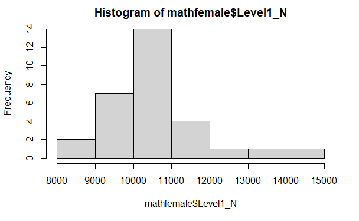

```r
hist(mathfemale$Level1_N)
```

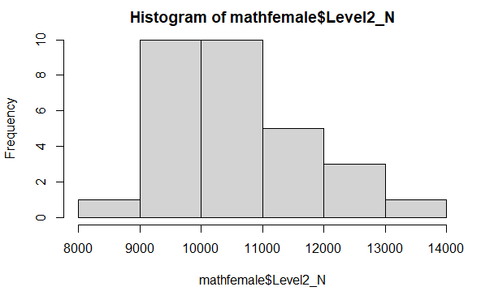

```r
hist(mathfemale$Level2_N)
```

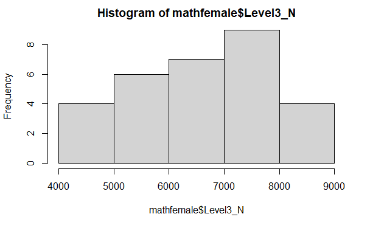

```r
hist(mathfemale$Level3_N)
```

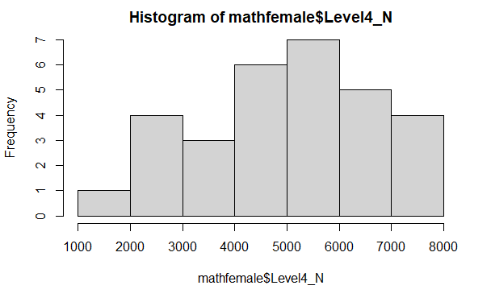

```r
hist(mathfemale$Level4_N)
```

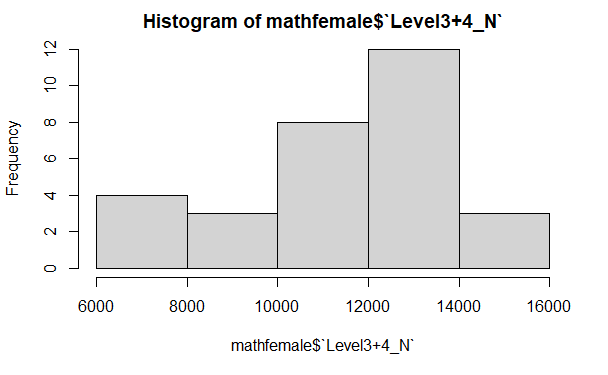

```r
hist(mathfemale$`Level3+4_N`)
```

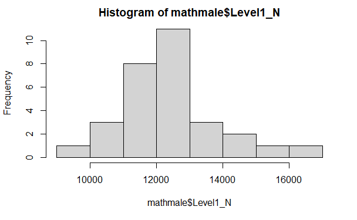

```r
hist(mathmale$Level1_N)
```

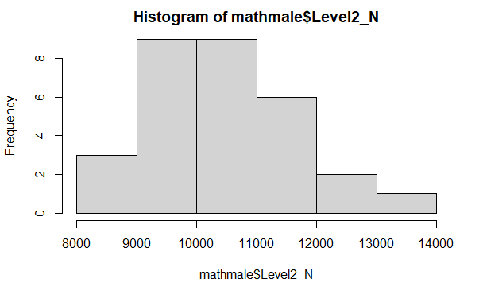

```r
hist(mathmale$Level2_N)
```

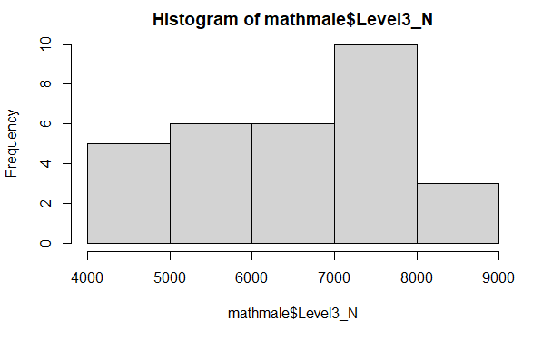

```r
hist(mathmale$Level3_N)
```

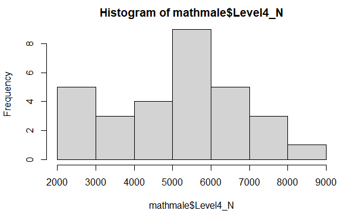

```r
hist(mathmale$Level4_N)
```

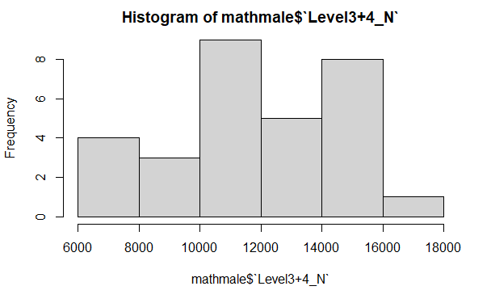

```r
hist(mathmale$`Level3+4_N`)
```

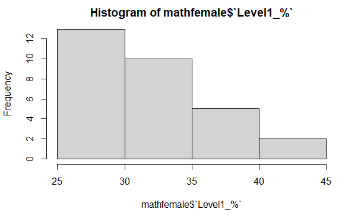

```r
hist(mathfemale$`Level1_%`)
```

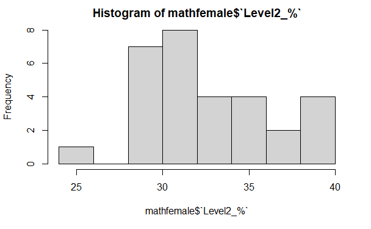

```r
hist(mathfemale$`Level2_%`)
```

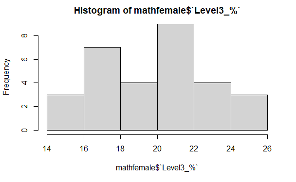

```r
hist(mathfemale$`Level3_%`)
```

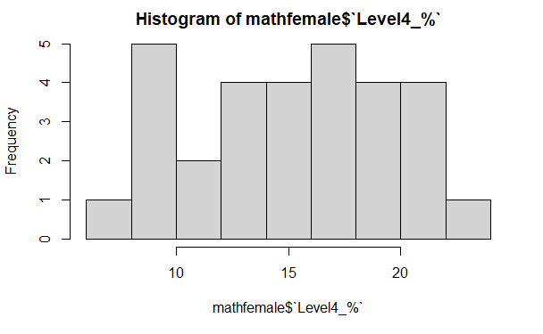

```r
hist(mathfemale$`Level4_%`)
```

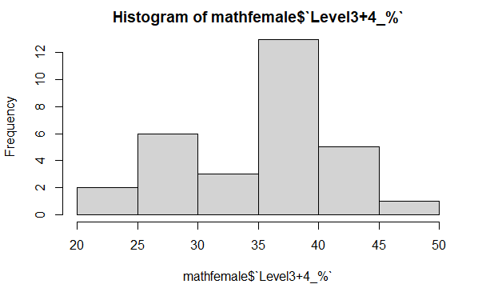

```r
hist(mathfemale$`Level3+4_%`)
```

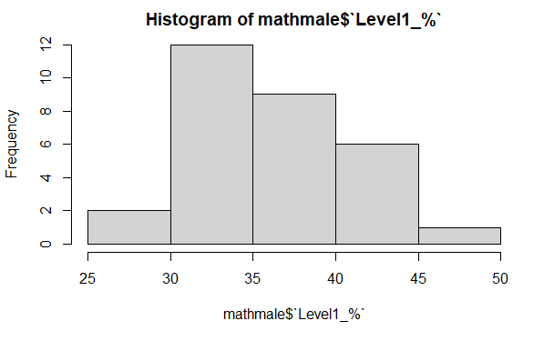

```r
hist(mathmale$`Level1_%`)
```

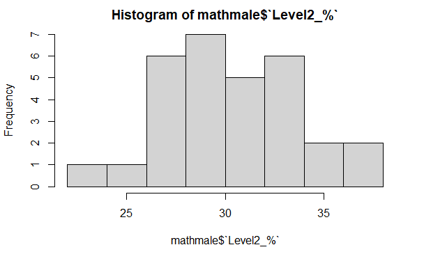

```r
hist(mathmale$`Level2_%`)
```

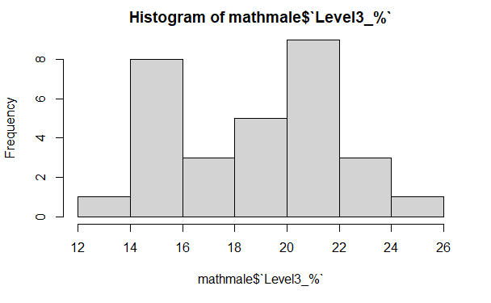

```r
hist(mathmale$`Level3_%`)
```

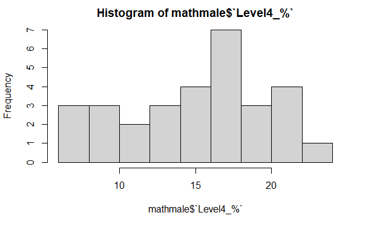

```r
hist(mathmale$`Level4_%`)
```

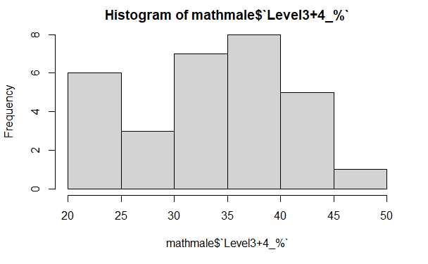

```r
hist(mathmale$`Level3+4_%`)
```

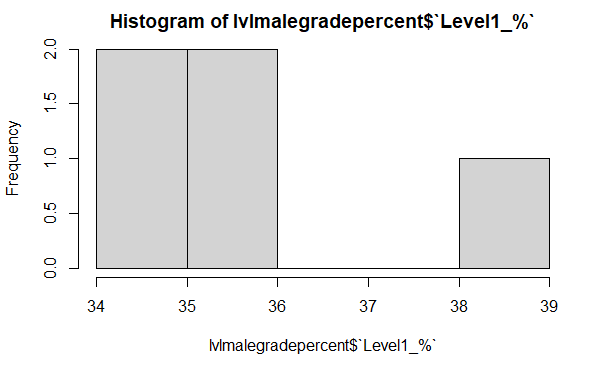

```r
hist(lvlmalegradepercent$`Level1_%`)
```

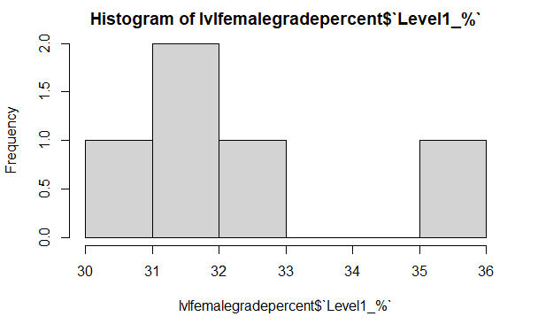

```r
hist(lvlfemalegradepercent$`Level1_%`)
```

pca on % data

```r
princomp(lvlbothpercent, cor = TRUE)
```

```
Call:
princomp(x = lvlbothpercent, cor = TRUE)

Standard deviations:
     Comp.1      Comp.2      Comp.3      Comp.4      Comp.5
1.863691469 1.006732755 0.716300066 0.005781035 0.004905642

 5  variables and  60 observations.
```

```r
summary(pc.crpercent <- princomp(lvlbothpercent, cor = TRUE))
```

```
Importance of components:
                          Comp.1    Comp.2    Comp.3       Comp.4
Standard deviation     1.8636915 1.0067328 0.7163001 5.781035e-03
Proportion of Variance 0.6946692 0.2027022 0.1026172 6.684074e-06
Cumulative Proportion  0.6946692 0.8973713 0.9999885 9.999952e-01
                             Comp.5
Standard deviation     4.905642e-03
Proportion of Variance 4.813065e-06
Cumulative Proportion  1.000000e+00
```

```r
loadings(pc.crpercent)
```

```
Loadings:
           Comp.1 Comp.2 Comp.3 Comp.4 Comp.5
Level1_%    0.441  0.551  0.184  0.236  0.643
Level2_%    0.332 -0.743 -0.337  0.164  0.445
Level3_%   -0.427  0.295 -0.739  0.420
Level4_%   -0.475 -0.239  0.553  0.625  0.144
Level3+4_% -0.536               -0.592  0.599

               Comp.1 Comp.2 Comp.3 Comp.4 Comp.5
SS loadings       1.0    1.0    1.0    1.0    1.0
Proportion Var    0.2    0.2    0.2    0.2    0.2
Cumulative Var    0.2    0.4    0.6    0.8    1.0
```

The first principal component used for the percentage of kids in each level explains 69.5% of the variability, and the second explains 20.3%, together explaining 89.7% of the variability

pca on lvl data

```r
princomp(lvlboth, cor = TRUE)
```

```
Call:
princomp(x = lvlboth, cor = TRUE)

Standard deviations:
      Comp.1       Comp.2       Comp.3       Comp.4       Comp.5
1.665553e+00 1.010691e+00 9.378120e-01 5.700381e-01 2.356080e-08

 5  variables and  60 observations.
```

```r
summary(pc.cr <- princomp(lvlboth, cor = TRUE))
```

```
Importance of components:
                          Comp.1    Comp.2    Comp.3     Comp.4
Standard deviation     1.6655534 1.0106913 0.9378120 0.57003811
Proportion of Variance 0.5548137 0.2042994 0.1758983 0.06498869
Cumulative Proportion  0.5548137 0.7591130 0.9350113 1.00000000
                             Comp.5
Standard deviation     2.356080e-08
Proportion of Variance 1.110223e-16
Cumulative Proportion  1.000000e+00
```

```r
loadings(pc.cr)
```

```
Loadings:
           Comp.1 Comp.2 Comp.3 Comp.4 Comp.5
Level1_N    0.318  0.381  0.767  0.407
Level2_N          -0.909  0.414
Level3_N   -0.492  0.157  0.453 -0.617  0.384
Level4_N   -0.552                0.663  0.493
Level3+4_N -0.592         0.160  0.115 -0.780

               Comp.1 Comp.2 Comp.3 Comp.4 Comp.5
SS loadings       1.0    1.0    1.0    1.0    1.0
Proportion Var    0.2    0.2    0.2    0.2    0.2
Cumulative Var    0.2    0.4    0.6    0.8    1.0
```

The first principal component in our example therefore explains 55.5% of the variability, and the second principal component explains 20.4%. Together, the first two principal components explain 75.9% of the variability.

By examining the principal component vectors above, we can infer the: + *the first principal component (PC1) roughly corresponds to levels 3,4 and 3+4.* + *The second component (PC2) is affected by level 2* more than the other 4 variables, so it roughly corresponds to the influence of level 2

The sample PCAs are:

$$\hat{Y}_1= 0.318 level 1 -0.492 level 3 - 0.552 level 4 - 0.592 level(3+4)$$

$$\hat{Y}_2= 0.381 level 1 - 0.909 level 2 + 0.157 level 3$$

$$\hat{Y}_3= 0.767 level 1 + 0.414 level 2 + 0.453 level 3 + 0.160 level (3+4)$$

$$\hat{Y}_4= 0.407 level 1 - 0.616 level 3 + 0.663 level 4 + 0.115 level (3+4)$$
$$\hat{Y}_5= 0.384 level 3 + 0.493 level 4 - 0.780 level (3+4)$$

now looking at the pca independently for male and female for levels

```r
princomp(lvlfemale, cor = TRUE)
```

```
Call:
princomp(x = lvlfemale, cor = TRUE)

Standard deviations:
   Comp.1    Comp.2    Comp.3    Comp.4    Comp.5
1.6342068 1.0461066 0.9910182 0.5029038 0.0000000

 5  variables and  30 observations.
```

```r
summary(pc.crf <- princomp(lvlfemale, cor = TRUE))
```

```
Importance of components:
                          Comp.1    Comp.2    Comp.3     Comp.4 Comp.5
Standard deviation     1.6342068 1.0461066 0.9910182 0.50290381      0
Proportion of Variance 0.5341263 0.2188678 0.1964234 0.05058245      0
Cumulative Proportion  0.5341263 0.7529941 0.9494176 1.00000000      1
```

```r
loadings(pc.crf)
```

```
Loadings:
           Comp.1 Comp.2 Comp.3 Comp.4 Comp.5
Level1_N    0.285  0.749  0.329  0.500
Level2_N           0.397 -0.918
Level3_N   -0.481  0.484  0.201 -0.584 -0.392
Level4_N   -0.568 -0.170         0.631 -0.494
Level3+4_N -0.604  0.136         0.107  0.776

               Comp.1 Comp.2 Comp.3 Comp.4 Comp.5
SS loadings       1.0    1.0    1.0    1.0    1.0
Proportion Var    0.2    0.2    0.2    0.2    0.2
Cumulative Var    0.2    0.4    0.6    0.8    1.0
```

The variability is explained for 53.4% for the first component, 21.9% for the second giving 75.3%

```r
princomp(lvlmale, cor = TRUE)
```

```
Call:
princomp(x = lvlmale, cor = TRUE)

Standard deviations:
   Comp.1    Comp.2    Comp.3    Comp.4    Comp.5
1.7571605 1.0136319 0.8371426 0.4291030 0.0000000

 5  variables and  30 observations.
```

```r
summary(pc.crm <- princomp(lvlmale, cor = TRUE))
```

```
Importance of components:
                          Comp.1    Comp.2    Comp.3     Comp.4 Comp.5
Standard deviation     1.7571605 1.0136319 0.8371426 0.42910300      0
Proportion of Variance 0.6175226 0.2054899 0.1401616 0.03682588      0
Cumulative Proportion  0.6175226 0.8230126 0.9631741 1.00000000      1
```

```r
loadings(pc.crm)
```

```
Loadings:
           Comp.1 Comp.2 Comp.3 Comp.4 Comp.5
Level1_N    0.426  0.283  0.656  0.555
Level2_N          -0.942  0.325
Level3_N   -0.461  0.162  0.628 -0.473 -0.379
Level4_N   -0.538        -0.178  0.658 -0.492
Level3+4_N -0.560         0.192  0.184  0.784

               Comp.1 Comp.2 Comp.3 Comp.4 Comp.5
SS loadings       1.0    1.0    1.0    1.0    1.0
Proportion Var    0.2    0.2    0.2    0.2    0.2
Cumulative Var    0.2    0.4    0.6    0.8    1.0
```

for males, the first component explains 61.8% of the variability, second 20.5%, giving 82.3% using the first two components. There is a difference of 7% explanation between genders when using the first two components in a pca analysis.